# R 다중회귀분석

Jang, Eunhee

2018년 6월 4일

### 다중회귀분석 목차

3. 다중 선형 회귀 분석 이론
4. 다중 선형 회귀 실습
- 스마트폰 만족도에 미치는 영향 분석
- 미국 대학 입학에 가장 영향이 높은 과목 분석
- 보혐회사의 보험료 인상에 미치는 요소분석

#### 3. 다중 선형 회귀 분석 이론

“독립변수가 여러개인 경우의 회귀분석”

단순선형 회귀 분석의 목적이 하나의 독립변수만 가지고 종속변수를 예측하기 위한 회귀모형을 만들기 위한 것이었다면  
독립변수(x)들을 가지고 종속변수(y)를 예측하기 위한 회귀모형을 만드는 것이다.  
예. 집값을 종속변수라고 보면 집값에 영향을 미치는 요소가 단순히 평수(독립변수)만 있는 것이 아니다.  
집값(종속변수) <- 평수, 교통, 학군, 범죄율, …

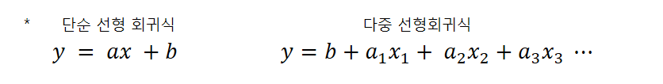

#### 문제 285. 스마트폰 만족감(종속변수)에 영향을 미치는 요소들 외관, 편의성, 유용성중에 가장 영향도가 높은것이 무엇이닞 알아내시오

```r
      ## 스마트폰 구매에 영향을 미치는 요소분석
      # 데이터 로드
      multi_hg <- read.csv("C:/data/multi_hg.csv")
      head(multi_hg)
```

```
##       외관   편의성   유용성 만족감
## 1  0.92028  2.26322  2.49969   5.00
## 2  0.35472  0.11779  1.02933   3.00
## 3 -0.51868  0.20008 -0.28899   3.00
## 4  1.27550  0.16089  0.72871   4.33
## 5  1.25506 -1.83269  0.31254   3.33
## 6 -0.49746 -0.96887  0.07472   4.00
```

```r
      # 다중회귀분석을한다.

      attach(multi_hg)
      lm(만족감~외관+편의성+유용성,data=multi_hg)
```

```
##
## Call:
## lm(formula = 만족감 ~ 외관 + 편의성 + 유용성, data = multi_hg)
##
## Coefficients:
## (Intercept)         외관       편의성       유용성
##      3.5136       0.2694       0.2105       0.1623
```

#### 문제 286.(점심시간문제) 미국 대학교 입학에 가장 영향을 미치는 요소가 무엇인지 알아내시오(정규화한후)

```r
 ## 미국대학 입학점수 데이터 분석

sports <- read.csv("C:/data/sports.csv")
      head(sports)
```

```
##   X academic sports    music acceptance
## 1 1    230.1   37.8 62.90909   81.85185
## 2 2     44.5   39.3 41.00000   38.51852
## 3 3     17.2   45.9 63.00000   34.44444
## 4 4    151.5   41.3 68.51852   68.51852
## 5 5    180.8   10.8 53.09091   47.77778
## 6 6      8.7   48.9 68.18182   26.66667
```

```r
normalize<-function(x) {
  return ( (x-min(x))/ ( max(x)-min(x)))
}


n_sports<-as.data.frame(lapply(sports[2:5],normalize))


#다중회귀분석

attach(n_sports)
lm(acceptance~.,data=n_sports)
```

```
##
## Call:
## lm(formula = acceptance ~ ., data = n_sports)
##
## Coefficients:
## (Intercept)     academic       sports        music
##     0.06122      0.48964      0.30195      0.11432
```

#### 문제 287. 두개의 csv 파일을 R로 로드하고 서울시 월별 평균대기오염정보 변수에 시군구 지역코드 컬럼을 생성하시오

```r
airpollution <- read.csv("C:/data/airpollution.csv")

loc_code <- read.csv("C:/data/area_code.csv")

cold <- read.csv("C:/data/cold.csv")

head(airpollution)
```

```
##     date district   NO2 ozone  CO   SO2 dust fine_dust
## 1 201805   강남구 0.022 0.027 0.4 0.004   28        18
## 2 201805 강남대로 0.035 0.022 0.6 0.004   40        24
## 3 201805   강동구 0.021 0.035 0.4 0.004   38        21
## 4 201805 강변북로 0.030 0.020 0.4 0.003   44        25
## 5 201805   강북구 0.013 0.041 0.4 0.002   31        15
## 6 201805   강서구 0.023 0.042 0.4 0.003   31        18
```

```r
ncol(airpollution)
```

```
## [1] 8
```

```r
head(loc_code)
```

```
##   city_code district_code district
## 1        11         11110   종로구
## 2        11         11140     중구
## 3        11         11170   용산구
## 4        11         11200   성동구
## 5        11         11215   광진구
## 6        11         11230 동대문구
```

```r
# airpollution 데이터에 code라는 컬럼추가
# install.packages("stringr")
library(stringr)

colnames(airpollution)<-c("date",   "district",   "CO2",   "ozone","CO",   "SO2",   "dust",   "fine_dust")
head(airpollution)
```

```
##     date district   CO2 ozone  CO   SO2 dust fine_dust
## 1 201805   강남구 0.022 0.027 0.4 0.004   28        18
## 2 201805 강남대로 0.035 0.022 0.6 0.004   40        24
## 3 201805   강동구 0.021 0.035 0.4 0.004   38        21
## 4 201805 강변북로 0.030 0.020 0.4 0.003   44        25
## 5 201805   강북구 0.013 0.041 0.4 0.002   31        15
## 6 201805   강서구 0.023 0.042 0.4 0.003   31        18
```

```r
colnames(loc_code) <-c("city_code",   "district_code",   "district")
head(loc_code)
```

```
##   city_code district_code district
## 1        11         11110   종로구
## 2        11         11140     중구
## 3        11         11170   용산구
## 4        11         11200   성동구
## 5        11         11215   광진구
## 6        11         11230 동대문구
```

```r
air <- merge(airpollution,loc_code,by="district")
```

#### 문제289. cold.csv 의 data 컬럼을 년도월, 년도월별 감기 건수를 출력하시오

```r
      # cold 데이터를 년도월, 년도월별 감기건수를 출력
cold_2<-aggregate(cnt~substr(cold$date,1,6)+cold$district_code, cold, sum)
colnames(cold_2) <- c("date","district_code","cnt")
head(cold_2)
```

```
##     date district_code   cnt
## 1 201401         11110 31655
## 2 201402         11110 35942
## 3 201403         11110 30333
## 4 201404         11110 30378
## 5 201405         11110 26261
## 6 201406         11110 18915
```

#### 문제 290. 감기데이터 분석

```r
airpol <-  read.csv("C:/data/airpollution.csv")

loc_code <-  read.csv("C:/data/area_code.csv")

cold <- read.csv("C:/data/cold.csv")

cold_code <- merge(cold, loc_code )


cold_code <- cold_code[,-1]

cold_code$date <- substr(cold_code$date,1,6)


m <- aggregate(cnt ~ date + district, cold_code, sum)

airpol2 <- merge(airpol, m)

#-- 정규화

normalize <- function(x) {
  return ( (x-min(x)) / (max(x) - min(x))  ) }


airpol2_n  <- as.data.frame(lapply(airpol2[3:9] ,normalize))

#-- 회귀분석

attach(airpol2_n)
m6<-lm(cnt ~ (NO2 + ozone + CO + SO2 + dust+ fine_dust), data=airpol2_n )

summary(m6)
```

```
##
## Call:
## lm(formula = cnt ~ (NO2 + ozone + CO + SO2 + dust + fine_dust),
##     data = airpol2_n)
##
## Residuals:
##      Min       1Q   Median       3Q      Max
## -0.30583 -0.08223 -0.01913  0.05378  0.67779
##
## Coefficients:
##             Estimate Std. Error t value Pr(>|t|)
## (Intercept)  0.10436    0.02697   3.870 0.000117 ***
## NO2          0.19125    0.03714   5.149 3.22e-07 ***
## ozone       -0.01393    0.02791  -0.499 0.617827
## CO           0.15594    0.03057   5.101 4.12e-07 ***
## SO2          0.09782    0.03309   2.956 0.003199 **
## dust         0.11498    0.04246   2.708 0.006894 **
## fine_dust   -0.12586    0.03952  -3.184 0.001502 **
## ---
## Signif. codes:  0 '***' 0.001 '**' 0.01 '*' 0.05 '.' 0.1 ' ' 1
##
## Residual standard error: 0.1354 on 893 degrees of freedom
## Multiple R-squared:  0.2193, Adjusted R-squared:  0.214
## F-statistic:  41.8 on 6 and 893 DF,  p-value: < 2.2e-16
```

  > > 보험료인상에 대한 정확한 수치값(금액)을 보기 위하여 정규화하지 않는다.

```r
      # 보험 데이터를 R로 로드한다.

      insurance <- read.csv("C:/data/insurance.csv")

      head(insurance)
```

```
##   age    sex  bmi children smoker    region expenses
## 1  19 female 27.9        0    yes southwest 16884.92
## 2  18   male 33.8        1     no southeast  1725.55
## 3  28   male 33.0        3     no southeast  4449.46
## 4  33   male 22.7        0     no northwest 21984.47
## 5  32   male 28.9        0     no northwest  3866.86
## 6  31 female 25.7        0     no southeast  3756.62
```

```r
      #독립변수와 종속변수간의 상관관계 분석

      cor(insurance[,c(1,3,4,7)])
```

```
##                age        bmi   children   expenses
## age      1.0000000 0.10934101 0.04246900 0.29900819
## bmi      0.1093410 1.00000000 0.01264471 0.19857626
## children 0.0424690 0.01264471 1.00000000 0.06799823
## expenses 0.2990082 0.19857626 0.06799823 1.00000000
```

```r
      # 회귀함수 lm()을 이용하여 독립변수들의 회귀모수를 확인

      lm(expenses~.,data=insurance)
```

```
##
## Call:
## lm(formula = expenses ~ ., data = insurance)
##
## Coefficients:
##     (Intercept)              age          sexmale              bmi
##        -11941.6            256.8           -131.4            339.3
##        children        smokeryes  regionnorthwest  regionsoutheast
##           475.7          23847.5           -352.8          -1035.6
## regionsouthwest
##          -959.3
```

```r
      # 보험 데이터를 R로 로드한다.

      insurance <- read.csv("C:/data/insurance.csv")

      head(insurance)
```

```
##   age    sex  bmi children smoker    region expenses
## 1  19 female 27.9        0    yes southwest 16884.92
## 2  18   male 33.8        1     no southeast  1725.55
## 3  28   male 33.0        3     no southeast  4449.46
## 4  33   male 22.7        0     no northwest 21984.47
## 5  32   male 28.9        0     no northwest  3866.86
## 6  31 female 25.7        0     no southeast  3756.62
```

```r
      #정규화

      normalize <- function(x) {
        return ( (x-min(x)) / (max(x) - min(x))  ) }


      insurance_n  <- as.data.frame(lapply(insurance[c(1,3,4,7)] ,normalize))
      head(insurance_n)
```

```
##          age       bmi children    expenses
## 1 0.02173913 0.3207547      0.0 0.251610731
## 2 0.00000000 0.4797844      0.2 0.009635976
## 3 0.21739130 0.4582210      0.6 0.053115187
## 4 0.32608696 0.1805930      0.0 0.333010048
## 5 0.30434783 0.3477089      0.0 0.043815692
## 6 0.28260870 0.2614555      0.0 0.042056034
```

```r
      #독립변수와 종속변수간의 상관관계 분석

      cor(insurance_n[,c("age","bmi","children","expenses")])
```

```
##                age        bmi   children   expenses
## age      1.0000000 0.10934101 0.04246900 0.29900819
## bmi      0.1093410 1.00000000 0.01264471 0.19857626
## children 0.0424690 0.01264471 1.00000000 0.06799823
## expenses 0.2990082 0.19857626 0.06799823 1.00000000
```

```r
      # 회귀함수 lm()을 이용하여 독립변수들의 회귀모수를 확인

      lm(expenses~.,data=insurance)
```

```
##
## Call:
## lm(formula = expenses ~ ., data = insurance)
##
## Coefficients:
##     (Intercept)              age          sexmale              bmi
##        -11941.6            256.8           -131.4            339.3
##        children        smokeryes  regionnorthwest  regionsoutheast
##           475.7          23847.5           -352.8          -1035.6
## regionsouthwest
##          -959.3
```

### ■ R 스퀘어값 비교

#### 문제 290. 보험 데이터의 결정계수를 확인하는데 독립변수 BMI, AGE, CHILDREN,SEX,SMOKER,REGION로 다 넣고 확인하시오

```r
      # 보험 데이터를 R로 로드한다.

      insurance <- read.csv("C:/data/insurance.csv")

      head(insurance)
```

```
##   age    sex  bmi children smoker    region expenses
## 1  19 female 27.9        0    yes southwest 16884.92
## 2  18   male 33.8        1     no southeast  1725.55
## 3  28   male 33.0        3     no southeast  4449.46
## 4  33   male 22.7        0     no northwest 21984.47
## 5  32   male 28.9        0     no northwest  3866.86
## 6  31 female 25.7        0     no southeast  3756.62
```

```r
      # 회귀함수 lm()을 이용하여 독립변수들의 회귀모수를 확인

      m6<-lm(expenses~.,data=insurance)


       #R 스퀘어 값 비교

       summary(m6)
```

```
##
## Call:
## lm(formula = expenses ~ ., data = insurance)
##
## Residuals:
##      Min       1Q   Median       3Q      Max
## -11302.7  -2850.9   -979.6   1383.9  29981.7
##
## Coefficients:
##                 Estimate Std. Error t value Pr(>|t|)
## (Intercept)     -11941.6      987.8 -12.089  < 2e-16 ***
## age                256.8       11.9  21.586  < 2e-16 ***
## sexmale           -131.3      332.9  -0.395 0.693255
## bmi                339.3       28.6  11.864  < 2e-16 ***
## children           475.7      137.8   3.452 0.000574 ***
## smokeryes        23847.5      413.1  57.723  < 2e-16 ***
## regionnorthwest   -352.8      476.3  -0.741 0.458976
## regionsoutheast  -1035.6      478.7  -2.163 0.030685 *
## regionsouthwest   -959.3      477.9  -2.007 0.044921 *
## ---
## Signif. codes:  0 '***' 0.001 '**' 0.01 '*' 0.05 '.' 0.1 ' ' 1
##
## Residual standard error: 6062 on 1329 degrees of freedom
## Multiple R-squared:  0.7509, Adjusted R-squared:  0.7494
## F-statistic: 500.9 on 8 and 1329 DF,  p-value: < 2.2e-16
```

#### 문제 291. 흡연자는 비흡연자보다 의료비가 23,847 달러 더 증가하는지를 회귀분석으로 확인하시오

```r
      # 보험 데이터를 R로 로드한다.

      insurance <- read.csv("C:/data/insurance.csv")

      head(insurance)
```

```
##   age    sex  bmi children smoker    region expenses
## 1  19 female 27.9        0    yes southwest 16884.92
## 2  18   male 33.8        1     no southeast  1725.55
## 3  28   male 33.0        3     no southeast  4449.46
## 4  33   male 22.7        0     no northwest 21984.47
## 5  32   male 28.9        0     no northwest  3866.86
## 6  31 female 25.7        0     no southeast  3756.62
```

```r
      # 회귀함수 lm()을 이용하여 독립변수들의 회귀모수를 확인
      attach(insurance)

      lm(expenses~.,data=insurance)
```

```
##
## Call:
## lm(formula = expenses ~ ., data = insurance)
##
## Coefficients:
##     (Intercept)              age          sexmale              bmi
##        -11941.6            256.8           -131.4            339.3
##        children        smokeryes  regionnorthwest  regionsoutheast
##           475.7          23847.5           -352.8          -1035.6
## regionsouthwest
##          -959.3
```

#### 문제 292. 부양가족이 한명 더 늘어날 때마다 의료비는 얼마나 증가하는가?>

```r
      # 보험 데이터를 R로 로드한다.


      insurance <- read.csv("C:/data/insurance.csv")

      head(insurance)
```

```
##   age    sex  bmi children smoker    region expenses
## 1  19 female 27.9        0    yes southwest 16884.92
## 2  18   male 33.8        1     no southeast  1725.55
## 3  28   male 33.0        3     no southeast  4449.46
## 4  33   male 22.7        0     no northwest 21984.47
## 5  32   male 28.9        0     no northwest  3866.86
## 6  31 female 25.7        0     no southeast  3756.62
```

```r
      # 회귀함수 lm()을 이용하여 독립변수들의 회귀모수를 확인
      attach(insurance)
      lm(expenses~.,data=insurance)
```

```
##
## Call:
## lm(formula = expenses ~ ., data = insurance)
##
## Coefficients:
##     (Intercept)              age          sexmale              bmi
##        -11941.6            256.8           -131.4            339.3
##        children        smokeryes  regionnorthwest  regionsoutheast
##           475.7          23847.5           -352.8          -1035.6
## regionsouthwest
##          -959.3
```

#### 문제 293. 나이에따른 의료비 증가를 확인하시오

> > 256.8 달러

#### 문제 294. 흡연자는 비흡연자보다 의료비가 23,847 달러 증가한다고 했는데 흡연과 비만을 같이 있는 경우에 의료비가 얼마나 증가하는지 확인하시오

```r
    insurance <- read.csv("C:/data/insurance.csv")

      head(insurance)
```

```
##   age    sex  bmi children smoker    region expenses
## 1  19 female 27.9        0    yes southwest 16884.92
## 2  18   male 33.8        1     no southeast  1725.55
## 3  28   male 33.0        3     no southeast  4449.46
## 4  33   male 22.7        0     no northwest 21984.47
## 5  32   male 28.9        0     no northwest  3866.86
## 6  31 female 25.7        0     no southeast  3756.62
```

```r
      # 회귀함수 lm()을 이용하여 독립변수들의 회귀모수를 확인
      attach(insurance)
      lm(expenses~.,data=insurance)
```

```
##
## Call:
## lm(formula = expenses ~ ., data = insurance)
##
## Coefficients:
##     (Intercept)              age          sexmale              bmi
##        -11941.6            256.8           -131.4            339.3
##        children        smokeryes  regionnorthwest  regionsoutheast
##           475.7          23847.5           -352.8          -1035.6
## regionsouthwest
##          -959.3
```

```r
       #R 스퀘어 값 비교

       summary(m6)
```

```
##
## Call:
## lm(formula = expenses ~ ., data = insurance)
##
## Residuals:
##      Min       1Q   Median       3Q      Max
## -11302.7  -2850.9   -979.6   1383.9  29981.7
##
## Coefficients:
##                 Estimate Std. Error t value Pr(>|t|)
## (Intercept)     -11941.6      987.8 -12.089  < 2e-16 ***
## age                256.8       11.9  21.586  < 2e-16 ***
## sexmale           -131.3      332.9  -0.395 0.693255
## bmi                339.3       28.6  11.864  < 2e-16 ***
## children           475.7      137.8   3.452 0.000574 ***
## smokeryes        23847.5      413.1  57.723  < 2e-16 ***
## regionnorthwest   -352.8      476.3  -0.741 0.458976
## regionsoutheast  -1035.6      478.7  -2.163 0.030685 *
## regionsouthwest   -959.3      477.9  -2.007 0.044921 *
## ---
## Signif. codes:  0 '***' 0.001 '**' 0.01 '*' 0.05 '.' 0.1 ' ' 1
##
## Residual standard error: 6062 on 1329 degrees of freedom
## Multiple R-squared:  0.7509, Adjusted R-squared:  0.7494
## F-statistic: 500.9 on 8 and 1329 DF,  p-value: < 2.2e-16
```

```r
      # 비만과 흡연이 보험인상률에 미치는 영향

       m7<-lm(expenses ~ bmi:smoker, data=insurance)
      summary(m7)
```

```
##
## Call:
## lm(formula = expenses ~ bmi:smoker, data = insurance)
##
## Residuals:
##      Min       1Q   Median       3Q      Max
## -13676.8  -4417.4   -830.3   3084.2  30254.1
##
## Coefficients:
##               Estimate Std. Error t value Pr(>|t|)
## (Intercept)    1721.18     889.92   1.934   0.0533 .
## bmi:smokerno    213.93      28.63   7.472 1.43e-13 ***
## bmi:smokeryes  1007.16      30.37  33.160  < 2e-16 ***
## ---
## Signif. codes:  0 '***' 0.001 '**' 0.01 '*' 0.05 '.' 0.1 ' ' 1
##
## Residual standard error: 6347 on 1335 degrees of freedom
## Multiple R-squared:  0.7258, Adjusted R-squared:  0.7253
## F-statistic:  1766 on 2 and 1335 DF,  p-value: < 2.2e-16
```

#### ncs문제 풀기

```r
x <- c(72,72,70,43,48,54,51,52,73,45,60,62,64,47,51,74,88,64,56,56)
y <- c(176,172,182,160,163,165,168,163,182,148,170,166,172,160,163,170,182,174,164,160)
w_h <- as.data.frame(cbind(x,y))
library(stats)
attach(w_h)
models <- lm(y~x,data = w_h)
models$coefficients
```

```
## (Intercept)           x
## 130.6745490   0.6210558
```

```r
w_h
```

```
##     x   y
## 1  72 176
## 2  72 172
## 3  70 182
## 4  43 160
## 5  48 163
## 6  54 165
## 7  51 168
## 8  52 163
## 9  73 182
## 10 45 148
## 11 60 170
## 12 62 166
## 13 64 172
## 14 47 160
## 15 51 163
## 16 74 170
## 17 88 182
## 18 64 174
## 19 56 164
## 20 56 160
```

> 기울기: 0.62  
> 절편 : 130

#### 최적의 회귀선을 도출하는 방법:

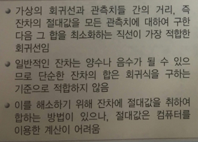

> 관측치와 회귀선간의 잔차를 제곱한 값을 모든 관측치에 대하여 구한 다음 그 값을 최소화하면 최적의 회귀선을 도출할 수 있음.

```r
w_h$diff_x <- w_h$x - mean(w_h$x)
w_h$diff_y <- w_h$y - mean(w_h$y)
w_h$diff_multi <- w_h$diff_x * w_h$diff_y
w_h$diff_power <- w_h$diff_x^2

w_h
```

```
##     x   y diff_x diff_y diff_multi diff_power
## 1  72 176   11.9      8       95.2     141.61
## 2  72 172   11.9      4       47.6     141.61
## 3  70 182    9.9     14      138.6      98.01
## 4  43 160  -17.1     -8      136.8     292.41
## 5  48 163  -12.1     -5       60.5     146.41
## 6  54 165   -6.1     -3       18.3      37.21
## 7  51 168   -9.1      0        0.0      82.81
## 8  52 163   -8.1     -5       40.5      65.61
## 9  73 182   12.9     14      180.6     166.41
## 10 45 148  -15.1    -20      302.0     228.01
## 11 60 170   -0.1      2       -0.2       0.01
## 12 62 166    1.9     -2       -3.8       3.61
## 13 64 172    3.9      4       15.6      15.21
## 14 47 160  -13.1     -8      104.8     171.61
## 15 51 163   -9.1     -5       45.5      82.81
## 16 74 170   13.9      2       27.8     193.21
## 17 88 182   27.9     14      390.6     778.41
## 18 64 174    3.9      6       23.4      15.21
## 19 56 164   -4.1     -4       16.4      16.81
## 20 56 160   -4.1     -8       32.8      16.81
```

```r
sum(w_h$diff_multi)
```

```
## [1] 1673
```

```r
sum(w_h$diff_power)
```

```
## [1] 2693.8
```

```r
# 회귀선의 기울기
b1 <- sum(w_h$diff_multi) / sum(w_h$diff_power)
b1
```

```
## [1] 0.6210558
```

```r
# 회귀선의 절편
b0 <- mean(y) - b1 * mean(x)
b0
```

```
## [1] 130.6745
```

#### y_hat

```r
w_h$y_hat <- b1 * w_h$x + b0
w_h
```

```
##     x   y diff_x diff_y diff_multi diff_power    y_hat
## 1  72 176   11.9      8       95.2     141.61 175.3906
## 2  72 172   11.9      4       47.6     141.61 175.3906
## 3  70 182    9.9     14      138.6      98.01 174.1485
## 4  43 160  -17.1     -8      136.8     292.41 157.3799
## 5  48 163  -12.1     -5       60.5     146.41 160.4852
## 6  54 165   -6.1     -3       18.3      37.21 164.2116
## 7  51 168   -9.1      0        0.0      82.81 162.3484
## 8  52 163   -8.1     -5       40.5      65.61 162.9694
## 9  73 182   12.9     14      180.6     166.41 176.0116
## 10 45 148  -15.1    -20      302.0     228.01 158.6221
## 11 60 170   -0.1      2       -0.2       0.01 167.9379
## 12 62 166    1.9     -2       -3.8       3.61 169.1800
## 13 64 172    3.9      4       15.6      15.21 170.4221
## 14 47 160  -13.1     -8      104.8     171.61 159.8642
## 15 51 163   -9.1     -5       45.5      82.81 162.3484
## 16 74 170   13.9      2       27.8     193.21 176.6327
## 17 88 182   27.9     14      390.6     778.41 185.3275
## 18 64 174    3.9      6       23.4      15.21 170.4221
## 19 56 164   -4.1     -4       16.4      16.81 165.4537
## 20 56 160   -4.1     -8       32.8      16.81 165.4537
```

```r
w_m <- mean(w_h$y)

w_h$sst <- (w_h$y - w_m)^2
w_h$sse <- (w_h$y - w_h$y_hat)^2
w_h$ssr <- (w_h$y_hat - w_m)^2

w_h
```

```
##     x   y diff_x diff_y diff_multi diff_power    y_hat sst          sse
## 1  72 176   11.9      8       95.2     141.61 175.3906  64 3.714128e-01
## 2  72 172   11.9      4       47.6     141.61 175.3906  16 1.149592e+01
## 3  70 182    9.9     14      138.6      98.01 174.1485 196 6.164681e+01
## 4  43 160  -17.1     -8      136.8     292.41 157.3799  64 6.864680e+00
## 5  48 163  -12.1     -5       60.5     146.41 160.4852  25 6.324092e+00
## 6  54 165   -6.1     -3       18.3      37.21 164.2116   9 6.216378e-01
## 7  51 168   -9.1      0        0.0      82.81 162.3484   0 3.194067e+01
## 8  52 163   -8.1     -5       40.5      65.61 162.9694  25 9.334025e-04
## 9  73 182   12.9     14      180.6     166.41 176.0116 196 3.586070e+01
## 10 45 148  -15.1    -20      302.0     228.01 158.6221 400 1.128281e+02
## 11 60 170   -0.1      2       -0.2       0.01 167.9379   4 4.252279e+00
## 12 62 166    1.9     -2       -3.8       3.61 169.1800   4 1.011244e+01
## 13 64 172    3.9      4       15.6      15.21 170.4221  16 2.489713e+00
## 14 47 160  -13.1     -8      104.8     171.61 159.8642  64 1.844990e-02
```

[output cut: 27 more lines]

```r
sum((b1 * w_h$x + b0 - mean(w_h$y))^2) / sum((w_h$y - mean(w_h$y))^2)
```

```
## [1] 0.7296533
```

```r
summary(models)
```

```
##
## Call:
## lm(formula = y ~ x, data = w_h)
##
## Residuals:
##      Min       1Q   Median       3Q      Max
## -10.6221  -3.2169   0.6305   2.5411   7.8515
##
## Coefficients:
##             Estimate Std. Error t value Pr(>|t|)
## (Intercept) 130.6746     5.4541   23.96 4.17e-15 ***
## x             0.6211     0.0891    6.97 1.65e-06 ***
## ---
## Signif. codes:  0 '***' 0.001 '**' 0.01 '*' 0.05 '.' 0.1 ' ' 1
##
## Residual standard error: 4.625 on 18 degrees of freedom
## Multiple R-squared:  0.7297, Adjusted R-squared:  0.7146
## F-statistic: 48.58 on 1 and 18 DF,  p-value: 1.645e-06
```

#### 문제 295.

```r
my_r_func <- function() {
  rm()
 y <- " ######################################################### \n # 1. 막대그래프              11. Decision Tree 머신러닝 \n # 2. 원형그래프              12. 규칙기반 oneR/Jriper        \n # 3. 산포도 그래프          13. 단순 회귀        \n # 4. 워드 클라우드                          \n # 5. 사분위수 그래프                                    \n # 6. 분산과 표준편차                                    \n # 7. 정규분포와 히스토그램                              \n # 8. 산포도와 회귀직선                                  \n # 9. knn 머신러닝                                       \n # 10. naive bayes 머신러닝                              \n ######################################################### "
   cat(y)

    ########### 1. 패키지 설치
# 현재 컴퓨터에 필요한 패키지 설치
# 만약 패키지가 존재하지 않는 경우에만 설치

  packages <- c("XML","stringr","rJava","KoNLP","wordcloud","lubridate","data.table","e1071","plyr","outliers","FSelector","gmodels","fBasics","fBasics","class","rpart","stats","RWeka")

  if (length(setdiff(packages, rownames(installed.packages()))) > 0) {
    install.packages(setdiff(packages, rownames(installed.packages())))
  }

  library(data.table)
  # x3 <- menu( c("막대그래프", "원형그래프", "산포도 그래프", "워드 클라우드", "사분위수 그래프", "분산과 표준편차","정규분포와 히스토그램","산포도와 회귀직선"
  #               "knn 머신러닝", "naive bayes 머신러닝","Decision Tree 머신러닝","규칙기반 oneR/Jriper","단순 회귀") ,
  #             title ='원하는 그래프를 선택하세요 ', graphics=T)
  x3 <- as.numeric(readline(prompt = "원하는 그래프를 선택하세요"))
  switch(x3,
        barchart={
          table <- get(readline(prompt = "테이블을 입력하세요~ "))
          x  <- menu( colnames(table) , title ='sum할 컬럼명(number)을 입력하세요 ')
          x1 <- menu( colnames(table) , title ='기준이될 컬럼명을 입력하세요 ')
          x2 <- menu( colnames(table) , title ='그루핑할 컬럼을 입력하세요 ')
          y <- tapply(table[, x], list(table[,x2], table[,x1]), sum)
          y[is.na(y)] <- 0

          barplot(y, col = rainbow(length(y)), beside = T)
          legend("topright", fill = rainbow(14), legend = rownames(y))

        },
        piechart={
          table <- get(readline(prompt = "테이블을 입력하세요~ "))
          x  <- menu( colnames(table) , title ='sum할 컬럼명(number)을 입력하세요 ')
          x1 <- menu( colnames(table) , title ='기준이될 컬럼명을 입력하세요 ')

          z <- tapply(table[,x], table[,x1], sum)

          rate <- round( z / sum(table[,x]) * 100, 1)
          pie(z, col= rainbow(length(names(z))), main = "Salary Pie Chart",
              labels = paste(names(z), rate,'%'))

        },
        plot = {
          table <- get(readline(prompt = "테이블을 입력하세요~ "))
          x1 <- menu(colnames(table) , title ='x축이될 컬럼명을 입력하세요 ')
          x2 <- menu(colnames(table) , title ='y축이될 컬럼명을 입력하세요 ')

          plot(table[,x1], table[,x2], xlab = colnames(table[x1]),
                     ylab = colnames(table[x2]), pch = '★', col ='Violet')
        },
        wordcloud = {
          data <- file.choose()
          file <- readLines(data)

          library(KoNLP)
          library(wordcloud)
          library(plyr)

          useSejongDic()
          nouns <- sapply(file, extractNoun, USE.NAMES = F)

          nouns <- unlist(nouns)
          # data 형식을 vector로 바꿈

          nouns <- nouns[nchar(nouns)>= 2]

          cnouns <- count(nouns)

          pal <- brewer.pal(6,"Dark2")

          pal <- pal[-(1)]

          x11()

          wordcloud(words=cnouns$x, freq=cnouns$freq, colors=pal, min.freq=5,
                    random.order=F)
        },
        boxplot = {
          table <- get(readline(prompt = "테이블명을 입력하세요~ "))
          x  <- menu( colnames(table) , title ='컬럼명을 입력하세요 ')

          boxplot(table[,x], horizontal = T)
        },
        var = {
            table <- get(readline(prompt = "분산을 시각화할 테이블명을 입력하시오 "))
            col <- menu(colnames(table), title = '분산을 시각화할 컬럼을 선택하세요.')
            x <- table[,col]
            cnt <- length(x)
            plot( x, main = paste("분산 =", round(var(x),3), "표준편차 =", round(sd(x),3)),
                  col = "Navy Blue",ylab = colnames(table[col]))
            lines(rep(mean(x),cnt), type = "l", col = "Violet Red")
        },
        hist = {
          table <- get(readline(prompt = "정규분포 곡선을 그릴 테이블 명을 입력하세요 "))
          col <- menu(colnames(table), title = "정규분포곡선을 그릴 컬럼명을 입력하세요 ")

          col <- table[order(table[col], decreasing = F), col]

          hist(col, col = topo.colors(8, alpha=0.7),ann = FALSE)
          par(new = T)
          plot(col, dnorm(col, mean = mean(col), sd = sd(col)), type = "l",
               main = paste(round(skewness(col),3),"정규분포 그래프"),ylab = "도수",
               axes = FALSE)
        },
        plot2 = {
          table_name <- readline(prompt = "산포도 그래프를 그릴 테이블 명을 입력하세요 ")
          table <- get(table_name)
          x_axis <- menu(colnames(table), title = "x 축 데이터를 입력하세요 ")
          y_axis <- menu(colnames(table), title = "y 축 데이터를 입력하세요 ")

          plot(table[,x_axis], table[,y_axis], main = paste(table_name, "산포도그래프"),
                xlab = colnames(table[x_axis]), ylab = colnames(table[y_axis]))
          model<- lm(table[,y_axis]~table[,x_axis])
          abline(model,col='red')
        },
        knn = {

          setwd("C:/data")
          #
          # data <- readline("분석할 csv파일명을 입력하세요 ")
          #
          print("분석할 csv파일명을 입력하세요")
          data<-file.choose()

          table1 <- na.omit(read.csv(data, stringsAsFactors = FALSE))

          col <- menu(colnames(table1), title = "라벨이 될 컬럼 이름을 입력하세요 ")

          col_n <- menu(colnames(table1), title = "제거할 컬럼 이름을 입력하세요 ")

          # colname으로 받아야함
          col1 <- colnames(table1)[col]

          normalize <- function(x) {
            return( (x-min(x))/ ( max(x)-min(x)))
          }

          # 불필요한 컬럼 삭제하기
          table1 <- table1[-col_n]

          # which : column이 위치한 숫자가 출력
          ncol <- which(colnames(table1) == col1)

          # 정규화
          table_n <- as.data.frame(lapply(table1[, -ncol],normalize))

          # z_score 표준화로 대체 사용가능
          # table_z <- as.data.frame(scale(table1[-ncol]))

          # training data 와 test data 바꾸기
          mm<-round(nrow(table_n) * 9/10)
```

```r
          table_train <- table_n[1:mm, ]
          table_test  <- table_n[(mm+1):nrow(table_n), ]

          table_train_label <- table1[1:mm, col1]
          table_test_label  <- table1[(mm+1):nrow(table_n), col1]


          # k 값 자동 생성

          library(caret)

          library(e1071)

          repeats = 20

          numbers = 10

          tunel = 10

          # "데이터가 부정확, 불완전 또는 불합리한가 어떤가를 확인하기 위해서 사용되는 처리"
          set.seed(1234)
          x = trainControl(method = "repeatedcv",

                           number = numbers,

                           repeats = repeats,

                           classProbs = TRUE,

                           summaryFunction = twoClassSummary)


          # normalize에서 label이 사라짐 -> cbind로 묶음

          model1 <- train(label~. , data = cbind(label = table_train_label, table_train), method = "knn",

                         preProcess = c("center","scale"),

                         trControl = x,

                         metric = "ROC",

                         tuneLength = tunel)



          # Summary of model
          k_n <- max(model1$bestTune)


          # knn 알고리즘
          library(class)

          result1 <- knn(train=table_train, test=table_test, cl= table_train_label, k = k_n )

          # 확률구하기
          prop.table( table(ifelse(table1[(mm+1):nrow(table_n), col1]==result1,"o","x" )))

          # 이원교차표
          library(gmodels)

          CrossTable( x= table_test_label, y= result1, prop.chisq=FALSE)



          # 예측할 환자정보
          print("예측할 환자정보를 입력하세요.")
          patient <- file.choose()
          table2 <- na.omit(read.csv(patient))


          # rbind 해서 normalize하면 안됨. 트레이닝은 전체 테이터로만 해야 함.
          col2 <- colnames(table2)[col]

          table2 <- table2[-col_n]

          # print(table2)
          ncol <- which(colnames(table2) == col2)
          table_test2 <- table2[,-ncol]
          table_test2 <- normalize(table_test2)

          # print(table_test2)

          result2 <- knn(train=table_train, test = table_test2, cl= table_train_label, k = k_n )

          return(paste(result2,"(으)로 예측됩니다"))
        },
        naive_bayes = {

          setwd("C:/data")

          print("분석할 csv파일명을 입력하세요 ")
          data<-file.choose()

          na.string <- NA

          table1 <- read.csv(data, stringsAsFactors = F, header = F, na.string = na.string)

          col <- menu(colnames(table1), title = "라벨이 될 컬럼 이름을 입력하세요 ")

          col1 <- menu(colnames(table1), title = "수정할 컬럼 이름을 입력하세요 ")

          ch1 <- readline(prompt = "제거할 문자를 입력하세요 ")

          lap <- readline(prompt = "laplace값을 입력하세요 ")

          # data 정제

          table1[which(table1[,col1] == ch1), nrow(table)] <- NA

          # 3. factor로 변환한다.

          for (i in 1:dim(table1)[2]) {
            table1[,i] <- factor(table1[,i])
          }

          # 4. 훈련데이터와 테스트 데이터로 나눈다.

          set.seed(1)

          # 행의 건수 확인
          train_cnt <- round(0.75 * dim(table1)[1])
          # shuffle 하는 방법 중 하나
          train_indx <- sample(1:dim(table1)[1], train_cnt, replace = F)

          table_train <- table1[train_indx,]
          table_test <- table1[-train_indx,]

          # 5. 나이브 베이즈 함수를 이용해서 독버섯과 일반 버섯을 분류하는 모델을 생성한다.

          library(e1071)
          # V1~: label(기준으로 사용), laplace: positive double controlling Laplace smoothing.
          # laplace로 공격적으로 필터링하는 정도를 조절할 수 있음
          model1 <- naiveBayes(table_train[,col]~. , data = table_train, laplace = as.numeric(lap))

          # 생성된 분류모델
          model1

          # 6. 모델로 테스트 데이터로 정확도 측성한다.
          # 예측하기
          result1 <- predict(model1, table_test[, -col])
          # head(result1)

          # 7. 이원 교차표로 분류의 최종 결과를 확인한다.
          library(gmodels)

          CrossTable(x = table_test[,col], y = result1)
                      # 실제              예측
        },
        Decision_Tree = {

          print("분석할 csv파일을 입력하세요 ")
          data <- file.choose()
          na.string <- NA
          # 연속형데이터는 factor로 변환하면....안돼
          table1 <- read.csv(data, header = T, na.string = na.string)

          d_col <- menu(c(colnames(table1),'non'), title="삭제할 컬럼을 선택하시오 ")

          table1 <- table1[,-d_col]

          l_col <- menu(colnames(table1), title="label이 될 컬럼을 선택하시오 ")
          trials <- readline(prompt = "trials 값을 입력하세요 ")

          # 분석 쿼리
          library(C50)
          library(gmodels)
          library(rpart)
          library(rattle)


          # 조절할 것1_set.seed()
          set.seed(11)
          table_shuffle <- table1[sample(nrow(table1)),]


          train_num <- round(0.7*nrow(table_shuffle),0)
          table_train <- table_shuffle[1:train_num, ]
          table_test <- table_shuffle[(train_num +1): nrow(table_shuffle), ]

          l_col <-  colnames(table1)[l_col]
          ncol1 <- which(colnames(table1) == l_col)

          # 조절할 것2_trials:laplace와 비슷
          model <- C5.0(table_train[ ,-ncol1], table_train[ ,ncol1], trials = as.numeric(trials))
          result <- predict(model, table_test[ ,-ncol1])

          CrossTable(x = table_test[,ncol1], y= result)

          # as.formula와 paste로 ~.을 붙여야한다.
          tree <- rpart(label~. , data=data.frame(table1[,-ncol1], label = table1[,l_col]),
                        control=rpart.control(minsplit=2))
          fancyRpartPlot(tree,palettes = c("Greys","RdPu"))
        },
        rule_based = {
          library(RWeka)
          library(gmodels)

          rm()
          setwd("C:/data")
          x3 <- menu( c("OneR","JRip") ,
                      title ='원하는 그래프를 선택하세요 ')

           print("분석할 csv파일명을 입력하세요 ")
          data<-file.choose()

          table1 <- read.csv(data, header = T)

          col <- menu(colnames(table1), title = "라벨이 될 컬럼 이름을 입력하세요 ")

          col1 <- colnames(table1)[col]


          set.seed(1)

          # 행의 건수 확인
          train_cnt <- round(0.75 * dim(table1)[1])
          # shuffle 하는 방법 중 하나
          train_indx <- sample(1:dim(table1)[1], train_cnt, replace = F)

          table_train <- table1[train_indx,]
          table_test <- table1[-train_indx,]
```

```r
          library(RWeka)

          switch(x3,
                 OneR = {
                                  # formula : 함수식
                   model1 <- OneR(as.formula(paste(col1,"~.")) , data = table_train)
                 },
                 JRip = {
                   model1 <- JRip(as.formula(paste(col1,"~.")), data = table_train)
                 }
                 )


          # 예측하기
          result1 <- predict(model1, table_test[, -col])

          # 이원 교차표로 분류의 최종 결과를 확인한다.

          CrossTable(x = table_test[,col], y = result1)
        },
        linear_regression ={
          library(stats)
          # 1. 데이터를 R로 로드한다.
          data<-file.choose()

          table1 <- read.csv(data, header = T)

          col1 <- menu(colnames(table1), title = "독립변수가 될 컬럼 이름을 입력하세요 ")
          col1
          col2 <- menu(colnames(table1), title = "종속변수가 될 컬럼 이름을 입력하세요 ")

          col1 <- colnames(table1)[col1]
          col1
          col2 <- colnames(table1)[col2]
          # 2. 데이터를 가지고 plot 그래프를 그린다.

          # 3. 데이터에 맞는 회귀모델을 만든다.
          attach(table1)
                      # y 축 ~ x 축
          model <- lm(as.formula(paste(col2,"~",col1)))
          r_squar <- round(summary(model)$r.squared,3)
          plot(as.formula(paste(col2,"~",col1)), data = table1, col = "Hot Pink", bg = "red",
               main = paste("y =", round(model$coefficients[2],3),"x +",round(model$coefficients[1],3),
                            "r-squar :",r_squar))
          abline(model, col = "blue", lwd = 3)

        }

  )

}

# my_r_func()
```

#### 행렬 만들기

```r
# 전치 행렬
a <- matrix(c(1:9),ncol = 3, nrow = 3, byrow = T)
# 정방 행렬
b <- matrix(c(1:9),ncol = 3, nrow = 3)

a*b
```

```
##      [,1] [,2] [,3]
## [1,]    1    8   21
## [2,]    8   25   48
## [3,]   21   48   81
```

```r
a%*%b
```

```
##      [,1] [,2] [,3]
## [1,]   14   32   50
## [2,]   32   77  122
## [3,]   50  122  194
```

```r
# 전치
t(a)
```

```
##      [,1] [,2] [,3]
## [1,]    1    4    7
## [2,]    2    5    8
## [3,]    3    6    9
```

```r
c <- matrix(c(1:4), nrow = 2, byrow = T)
c
```

```
##      [,1] [,2]
## [1,]    1    2
## [2,]    3    4
```

```r
# 역행렬 만들기
solve(c)
```

```
##      [,1] [,2]
## [1,] -2.0  1.0
## [2,]  1.5 -0.5
```

```r
round(c %*% solve(c))
```

```
##      [,1] [,2]
## [1,]    1    0
## [2,]    0    1
```

#### 연립방정식 구하기

x1 + 2x2 + 3x3 = 1 2x1 + 5x2 + 3x3 = 3 x1 + + 8x3 = -1

```r
A <- matrix(c(1,2,3,2,5,3,1,0,8),nrow = 3, ncol = 3, byrow =T)
A
```

```
##      [,1] [,2] [,3]
## [1,]    1    2    3
## [2,]    2    5    3
## [3,]    1    0    8
```

```r
X = matrix(c("x1","x2","x3"), nrow = 3)
X
```

```
##      [,1]
## [1,] "x1"
## [2,] "x2"
## [3,] "x3"
```

```r
B = matrix(c(1,3,-1),nrow = 3)
B
```

```
##      [,1]
## [1,]    1
## [2,]    3
## [3,]   -1
```

```r
# A 역행렬
A1 <- solve(A)

X1 <- round(A1%*%B)
cbind(X,X1)
```

```
##      [,1] [,2]
## [1,] "x1" "-1"
## [2,] "x2" "1"
## [3,] "x3" "0"
```

#### 베타 헷구하기

```r
reg <- function(y,x) {
  # 행렬로 변경하는 방법
  x <- as.matrix(x)
  # y절편 추가하기
  x <- cbind(Intercept = 1, x)
  # 베타 헷 구하는 식 r로 구현함
  b <- solve(t(x) %*% x) %*% t(x) %*% y
  colnames(b) <- "estimate"
  print(b)
}

multi_hg <- read.csv("C:/data/multi_hg.csv", header = T)
head(multi_hg)
```

```
##       외관   편의성   유용성 만족감
## 1  0.92028  2.26322  2.49969   5.00
## 2  0.35472  0.11779  1.02933   3.00
## 3 -0.51868  0.20008 -0.28899   3.00
## 4  1.27550  0.16089  0.72871   4.33
## 5  1.25506 -1.83269  0.31254   3.33
## 6 -0.49746 -0.96887  0.07472   4.00
```

```r
attach(multi_hg)
# library(stats)
model <- lm(만족감 ~ .,data = multi_hg)
model
```

```
##
## Call:
## lm(formula = 만족감 ~ ., data = multi_hg)
##
## Coefficients:
## (Intercept)         외관       편의성       유용성
##      3.5136       0.2694       0.2105       0.1623
```

```r
reg(y = multi_hg$만족감, x = multi_hg[-4])
```

```
##            estimate
## Intercept 3.5136006
## 외관      0.2694261
## 편의성    0.2105249
## 유용성    0.1623154
```

#### 문제296. 우주왕복선 챌린져호의 폭파원인인 o형링 파손에 영향을 주는 독립변수가 온도 말고도 다른 독립변수가 있는지 지금 만든 reg함수를 이용해서 확인하시오

```r
launch <- read.csv("C:/data/challenger2.csv",header = T)
head(launch)
```

```
##   distress_ct temperature field_check_pressure flight_num
## 1           0          66                   50          1
## 2           1          70                   50          2
## 3           0          69                   50          3
## 4           0          68                   50          4
## 5           0          67                   50          5
## 6           0          72                   50          6
```

```r
# distress_ct: o형링 파손수, temperature: 온도, field_check_pressure:압력, flight_id:비행기 num - 비행기 나이

reg(y = launch$distress_ct, x = launch[2:4])
```

```
##                          estimate
## Intercept             3.527093383
## temperature          -0.051385940
## field_check_pressure  0.001757009
## flight_num            0.014292843
```

```r
attach(launch)
library(stats)
model <- lm(distress_ct~.,data = launch)
# 결정계수 확인하기
summary(model)$r.squared
```

```
## [1] 0.3600072
```

#### 문제297. 베타 헷을 구하는 수학식 도출하는 과정을 풀이하시오

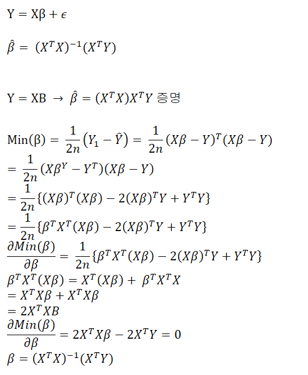

#### 문제 298. 나이가 올라감에 따라서 의료비 지출이 더 올라간다는 것을 R의 pairs함수로 확인하시오

```r
# insurance <-read.csv("C:/data/insurance.csv")
head(insurance)
```

```
##   age    sex  bmi children smoker    region expenses
## 1  19 female 27.9        0    yes southwest 16884.92
## 2  18   male 33.8        1     no southeast  1725.55
## 3  28   male 33.0        3     no southeast  4449.46
## 4  33   male 22.7        0     no northwest 21984.47
## 5  32   male 28.9        0     no northwest  3866.86
## 6  31 female 25.7        0     no southeast  3756.62
```

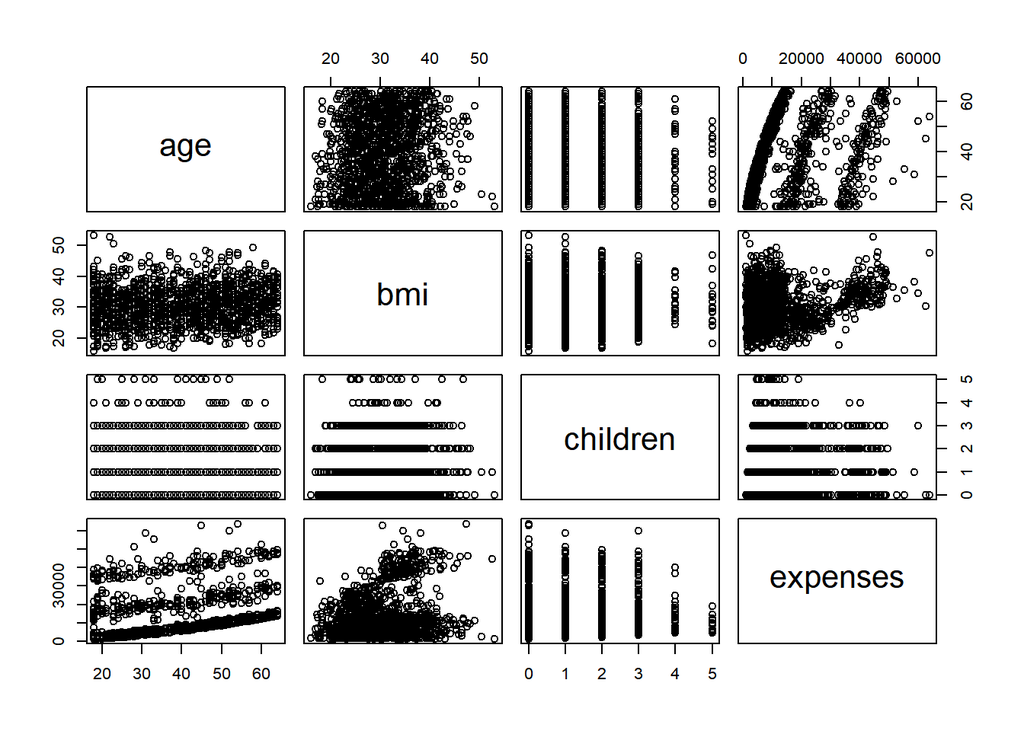

```r
pairs(insurance[c("age","bmi","children","expenses")])
```

#### 문제270. 숫자로 출력되게 하시오

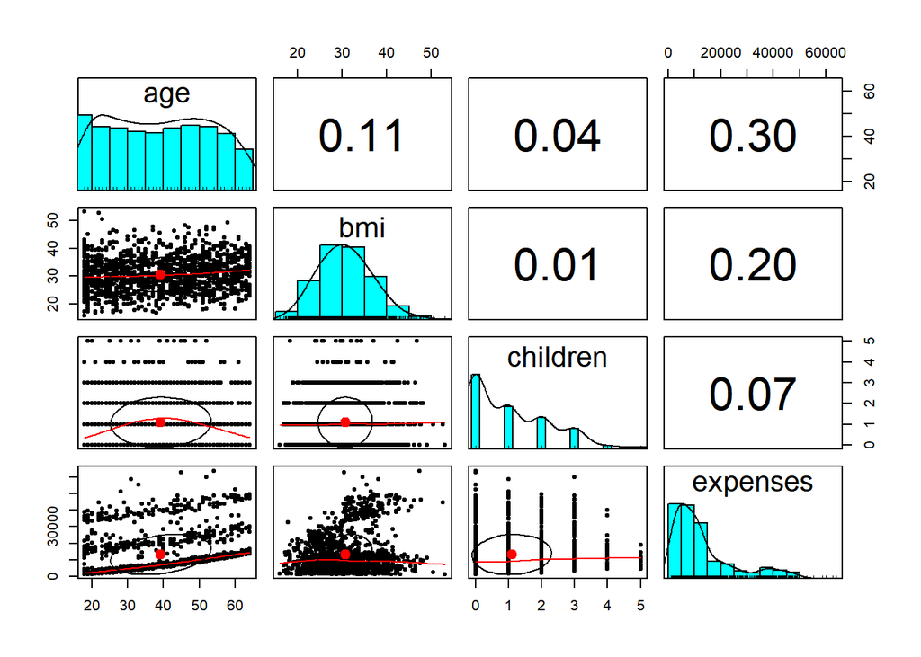

```r
# install.packages("psych")
library(psych)
pairs.panels(insurance[c("age","bmi","children","expenses")])
```

#### 문제300. lm함수를 이용해서 회귀분석을 하는데 종속변수를 expenses로 두고 독립변수를 age, children, bmi, sex, smoker, region으로 두고 회귀분석하시오

```r
ins_model <- lm(expenses~., data = insurance)
ins_model
```

```
##
## Call:
## lm(formula = expenses ~ ., data = insurance)
##
## Coefficients:
##     (Intercept)              age          sexmale              bmi
##        -11941.6            256.8           -131.4            339.3
##        children        smokeryes  regionnorthwest  regionsoutheast
##           475.7          23847.5           -352.8          -1035.6
## regionsouthwest
##          -959.3
```

> 결과: 1. 나이가 일년씩 더해질때마다 평균적으로 256달러의 의료비가 더 들고  
> 2. 자녀 한명이 추가됨에따라 의료비가 475달러 더 들고  
> 3.bim가 증가함에 따라서 연간 339달러의 의료비가 더 든다.

#### 남자가 여성에 비해 의료비가 131달러 적게 든다는 것을 성별을 더미코딩하여 독립변수로 추가해서 알아내시오

```r
# insurance$sex <- ifelse(insurance$sex == "male",1,0)
# lm()이 자동으로 더미코딩해줌
```

#### 문제302. 위의 회귀모델에서 결정계수를 확인하시오

```r
round(summary(ins_model)$r.squared,3)
```

```
## [1] 0.751
```

#### 문제 303. 나이에 대한 비선형적인 모델로 만듬

```r
insurance$age2 <- insurance$age^2

ins_model2 <- lm(expenses~., data = insurance)
round(summary(ins_model2)$r.squared,3)
```

```
## [1] 0.754
```

#### 문제304. bmi30이라는 더미 변수를 추가해서 bmi가 30 이상인 사람들은 더 의료비가 많이 들것이라는 예측을 하는 회귀모델의 결정계수를 확인해서 유의한 독립변수인지 확인하기

```r
insurance$bmi30 <- ifelse(insurance$bmi >= 30, 1, 0)

ins_model3 <- lm(expenses~., data = insurance)
round(summary(ins_model3)$r.squared,3)
```

```
## [1] 0.758
```

#### 문제305. bmi30*smoker를 추가해서 비만지수가 30 이상이면서 흡연자가 더 의료비가 많이 드는지 결정계수로 확인하시오

```r
ins_model4 <- lm(expenses~.+bmi30*smoker, data = insurance)
round(summary(ins_model4)$r.squared,3)
```

```
## [1] 0.866
```

```r
ins_model4
```

```
##
## Call:
## lm(formula = expenses ~ . + bmi30 * smoker, data = insurance)
##
## Coefficients:
##     (Intercept)              age          sexmale              bmi
##         139.005          -32.618         -496.769          119.771
##        children        smokeryes  regionnorthwest  regionsoutheast
##         678.602        13404.595         -279.166         -828.035
## regionsouthwest             age2            bmi30  smokeryes:bmi30
##       -1222.162            3.731         -997.935        19810.153
```

> smokeryes:bmi30 - 보험금 더 많이 책정한다.

#### 문제306. 나이도 많은데(나이 50기준) 비만(bmi30)이기까지하고 담배까지 피는 사람이 의료비가 더 많이 드는지 확인하기

```r
insurance$age50 <- ifelse(insurance$age >= 50, 1, 0)

ins_model5 <- lm(expenses~.+bmi30*smoker*age50, data = insurance)
round(summary(ins_model5)$r.squared,3)
```

```
## [1] 0.867
```

```r
ins_model5
```

```
##
## Call:
## lm(formula = expenses ~ . + bmi30 * smoker * age50, data = insurance)
##
## Coefficients:
##           (Intercept)                    age                sexmale
##             -561.7268                19.6311              -499.7791
##                   bmi               children              smokeryes
##              119.9316               682.1595             13674.6523
##       regionnorthwest        regionsoutheast        regionsouthwest
##             -270.8873              -807.7165             -1231.7228
##                  age2                  bmi30                  age50
##                2.7829             -1016.4399              1002.0917
##       smokeryes:bmi30            bmi30:age50        smokeryes:age50
##            19589.1972                -0.2423             -1147.9684
## smokeryes:bmi30:age50
##             1047.2611
```

### ■ 회귀트리

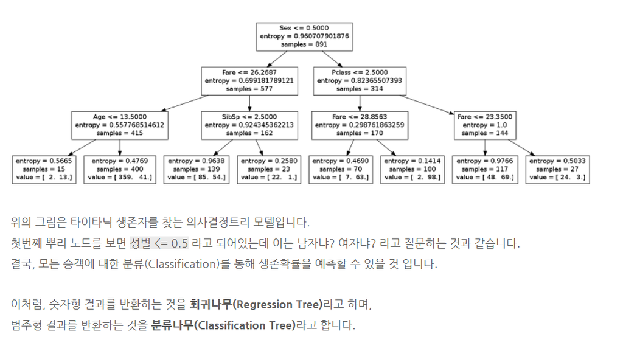

#### 와인데이터로 회귀 의사결정 트리 시각화

```r
# 1. 와인데이터에 대한 소개
wine <- read.csv("C:/data/whitewines.csv")
str(wine)
```

```
## 'data.frame':    4898 obs. of  12 variables:
##  $ fixed.acidity       : num  6.7 5.7 5.9 5.3 6.4 7 7.9 6.6 7 6.5 ...
##  $ volatile.acidity    : num  0.62 0.22 0.19 0.47 0.29 0.14 0.12 0.38 0.16 0.37 ...
##  $ citric.acid         : num  0.24 0.2 0.26 0.1 0.21 0.41 0.49 0.28 0.3 0.33 ...
##  $ residual.sugar      : num  1.1 16 7.4 1.3 9.65 0.9 5.2 2.8 2.6 3.9 ...
##  $ chlorides           : num  0.039 0.044 0.034 0.036 0.041 0.037 0.049 0.043 0.043 0.027 ...
##  $ free.sulfur.dioxide : num  6 41 33 11 36 22 33 17 34 40 ...
##  $ total.sulfur.dioxide: num  62 113 123 74 119 95 152 67 90 130 ...
##  $ density             : num  0.993 0.999 0.995 0.991 0.993 ...
##  $ pH                  : num  3.41 3.22 3.49 3.48 2.99 3.25 3.18 3.21 2.88 3.28 ...
##  $ sulphates           : num  0.32 0.46 0.42 0.54 0.34 0.43 0.47 0.47 0.47 0.39 ...
##  $ alcohol             : num  10.4 8.9 10.1 11.2 10.9 ...
##  $ quality             : int  5 6 6 4 6 6 6 6 6 7 ...
```

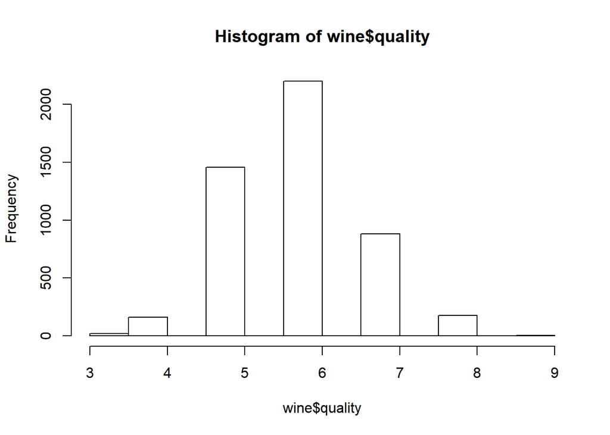

```r
#fixed.acidity       : 고정 산도
#volatile.acidity    : 휘발성 산도
#citric.acid         : 시트르산
#residual.sugar      : 잔류 설탕
#chlorides           : 염화물
#free.sulfur.dioxide : 자유 이산화황
#total.sulfur.dioxide: 총 이산화황
#density             : 밀도
#pH                  : pH
#sulphates           : 황산염
#alcohol             : 알코올
#quality             : 품질

# 2. 와인의 quality 데이터가 정규분포에 속하는 안정적인 데이터인지 확인
hist(wine$quality)
```

```r
# 3.wine데이터를 train데이터와 test데이터로 나눈다
data <- round(nrow(wine)*0.7)
wine_train <- wine[1:data,]
wine_test <- wine[(data+1):nrow(wine),]
nrow(wine_train)
```

```
## [1] 3429
```

```r
# 4. train데이터를 가지고 model을 생성한다.
library(rpart)
model <- rpart(quality~., data = wine_train)
model
```

```
## n= 3429
##
## node), split, n, deviance, yval
##       * denotes terminal node
##
##  1) root 3429 2698.323000 5.873724
##    2) alcohol< 10.85 2156 1284.250000 5.607143
##      4) volatile.acidity>=0.2275 1469  757.298800 5.436351
##        8) volatile.acidity>=0.3025 627  252.625200 5.259968 *
##        9) volatile.acidity< 0.3025 842  470.641300 5.567696 *
##      5) volatile.acidity< 0.2275 687  392.474500 5.972344 *
##    3) alcohol>=10.85 1273 1001.361000 6.325216
##      6) free.sulfur.dioxide< 11.5 84   99.559520 5.369048 *
##      7) free.sulfur.dioxide>=11.5 1189  819.577800 6.392767
##       14) alcohol< 11.76667 581  401.294300 6.184165
##         28) volatile.acidity>=0.48 7    4.857143 4.142857 *
##         29) volatile.acidity< 0.48 574  366.912900 6.209059 *
##       15) alcohol>=11.76667 608  368.842100 6.592105 *
```

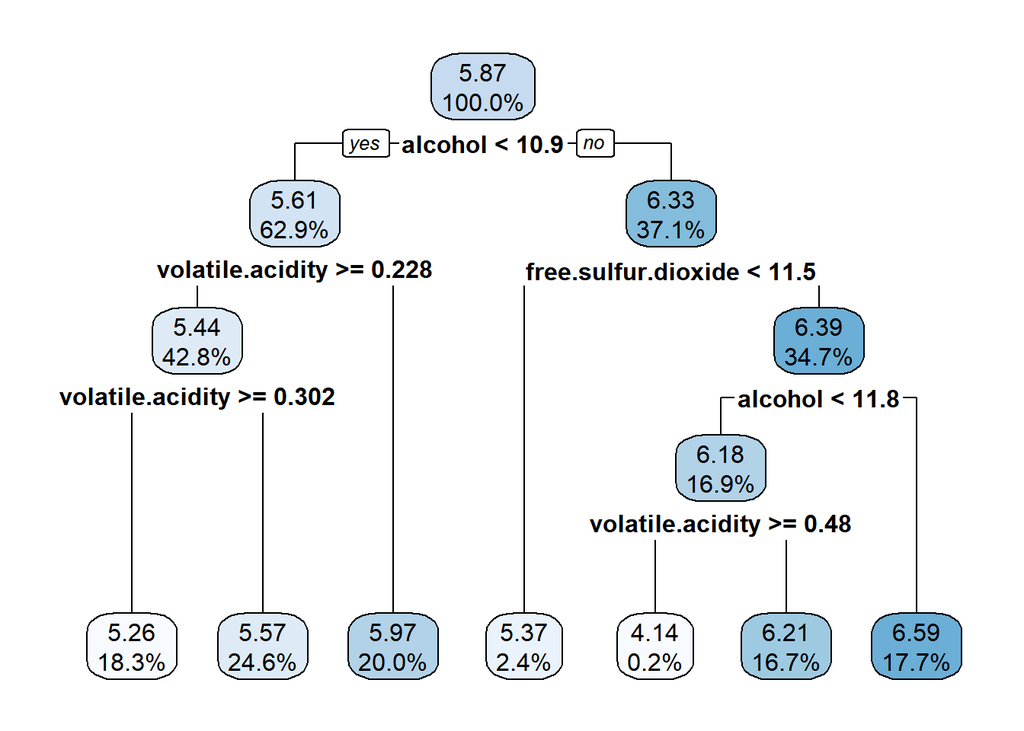

```r
# 5. 위의 model로 트리를 시각화하시오
library(rpart.plot)
rpart.plot(model, digits = 3)
```

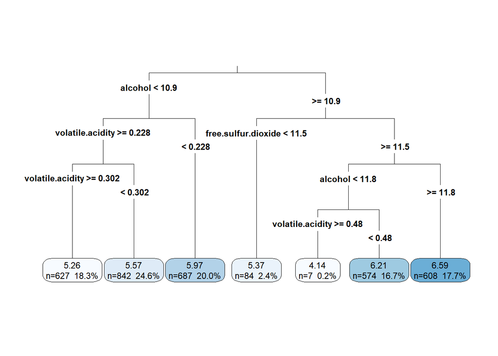

```r
rpart.plot(model, digits = 3, fallen.leaves = T, type = 3, extra = 101)
```

```r
# 6. 위에서 만든 모델로 test데이터의 label을 예측하기
# why label을 빼지 않고 하는거지?
result <- predict(model,wine_test)

# 7. 테스트 데이터의 실제 라벨과 예측결과를 비교한다.
table(ifelse( round(result) == wine_test$quality, 1, 0))
```

```
##
##   0   1
## 716 753
```

```r
# 8. 테스트 데이터의 라벨과 예측결과와 상관관계가 어떻게 되는지 확인한다.
cor(result,wine_test$quality)
```

```
## [1] 0.5353922
```

```r
# 9. 두 데이터간의 오차율을 확인
MAE <- function(actual, predicted){
  mean(abs(actual - predicted))
}

# 0.59로 상대적으로 높게 나옴 -> 개선의 여지 필요
MAE(result, wine_test$quality)
```

```
## [1] 0.5870644
```

> 개선방법: 회귀트리 –> 모델트리로 변경

### 모델트리?

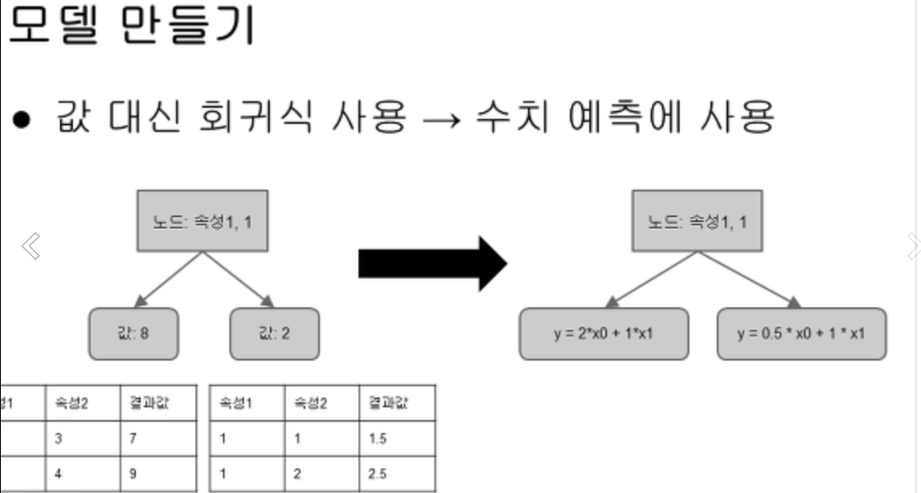

```r
# 10. 모델트리를 구현하기위한 패키지
library(RWeka)

# 11. 와인의 품질을 예측하는 모델을 생성한다.
model_tree <- M5P(quality~., data = wine_train)

# 12. 위에서 만든 모델로 test데이터의 label을 예측하기
# why label을 빼지 않고 하는거지?
model_result <- predict(model_tree,wine_test)

# 13. 테스트 데이터의 실제 라벨과 예측결과를 비교한다.
table(ifelse( round(model_result) == wine_test$quality, 1, 0))
```

```
##
##   0   1
## 662 807
```

```r
# 14. 테스트 데이터의 라벨과 예측결과와 상관관계가 어떻게 되는지 확인한다.
cor(model_result,wine_test$quality)
```

```
## [1] 0.6139651
```

```r
# 15. 두 데이터간의 오차율을 확인
# 0.55
MAE(model_result, wine_test$quality)
```

```
## [1] 0.5498993
```

#### 문제307. 보스턴 하우징 데이터를 이용해서 회귀 트리를 그리시오

[01] CRIM 자치시(town) 별 1인당 범죄율 [02] ZN 25,000 평방피트를 초과하는 거주지역의 비율 [03] INDUS 비소매상업지역이 점유하고 있는 토지의 비율 [04] CHAS 찰스강에 대한 더미변수(강의 경계에 위치한 경우는 1, 아니면 0) [05] NOX 10ppm 당 농축 일산화질소 [06] RM 주택 1가구당 평균 방의 개수 [07] AGE 1940년 이전에 건축된 소유주택의 비율 [08] DIS 5개의 보스턴 직업센터까지의 접근성 지수 [09] RAD 방사형 도로까지의 접근성 지수 [10] TAX 10,000 달러 당 재산세율 [11] PTRATIO 자치시(town)별 학생/교사 비율 [12] B 1000(Bk-0.63)^2, 여기서 Bk는 자치시별 흑인의 비율을 말함. [13] LSTAT 모집단의 하위계층의 비율(%) [14] MEDV 본인 소유의 주택가격(중앙값) (단위: $1,000) label: MEDV, cat.MEDV

```r
boston <- read.csv("C:/data/boston.csv")
str(boston)
```

```
## 'data.frame':    506 obs. of  15 variables:
##  $ CRIM     : num  0.00632 0.02731 0.02729 0.03237 0.06905 ...
##  $ ZN       : num  18 0 0 0 0 0 12.5 12.5 12.5 12.5 ...
##  $ INDUS    : num  2.31 7.07 7.07 2.18 2.18 2.18 7.87 7.87 7.87 7.87 ...
##  $ CHAS     : int  0 0 0 0 0 0 0 0 0 0 ...
##  $ NOX      : num  0.538 0.469 0.469 0.458 0.458 0.458 0.524 0.524 0.524 0.524 ...
##  $ RM       : num  6.58 6.42 7.18 7 7.15 ...
##  $ AGE      : num  65.2 78.9 61.1 45.8 54.2 58.7 66.6 96.1 100 85.9 ...
##  $ DIS      : num  4.09 4.97 4.97 6.06 6.06 ...
##  $ RAD      : int  1 2 2 3 3 3 5 5 5 5 ...
##  $ TAX      : int  296 242 242 222 222 222 311 311 311 311 ...
##  $ PTRATIO  : num  15.3 17.8 17.8 18.7 18.7 18.7 15.2 15.2 15.2 15.2 ...
##  $ B        : num  397 397 393 395 397 ...
##  $ LSTAT    : num  4.98 9.14 4.03 2.94 5.33 ...
##  $ MEDV     : num  24 21.6 34.7 33.4 36.2 28.7 22.9 27.1 16.5 18.9 ...
##  $ CAT..MEDV: int  0 0 1 1 1 0 0 0 0 0 ...
```

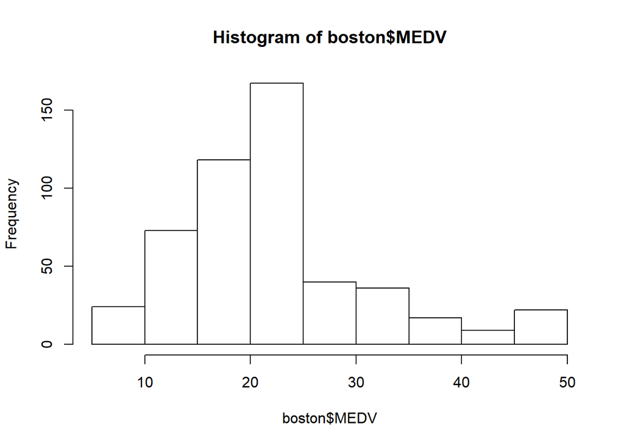

```r
# 2. 와인의 quality 데이터가 정규분포에 속하는 안정적인 데이터인지 확인
cat <- which(colnames(boston) == "CAT..MEDV")

boston <- boston[-cat]
hist(boston$MEDV)
```

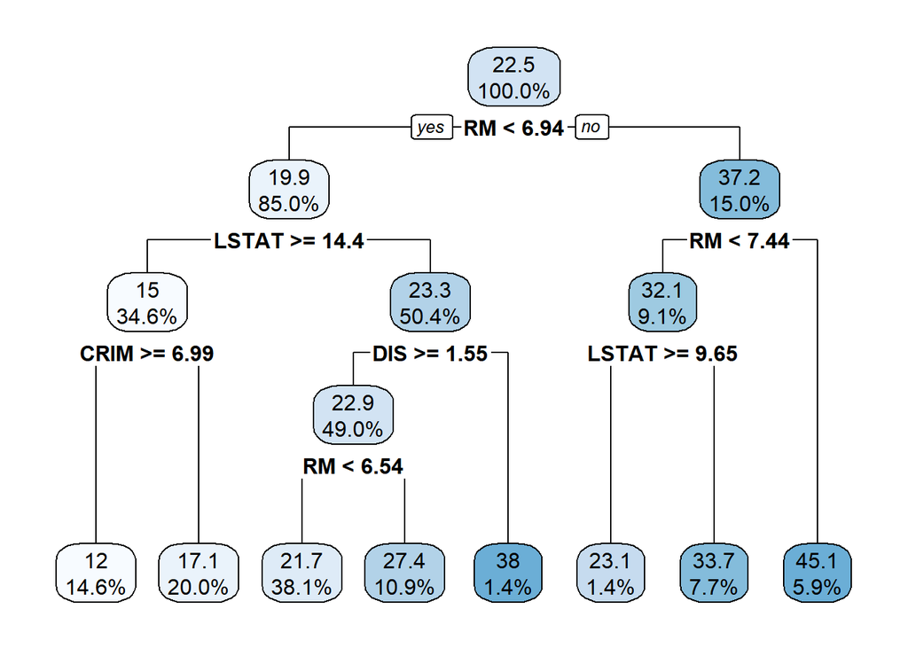

```r
model <- rpart(MEDV~., data = boston)

rpart.plot(model, digits = 3)
```

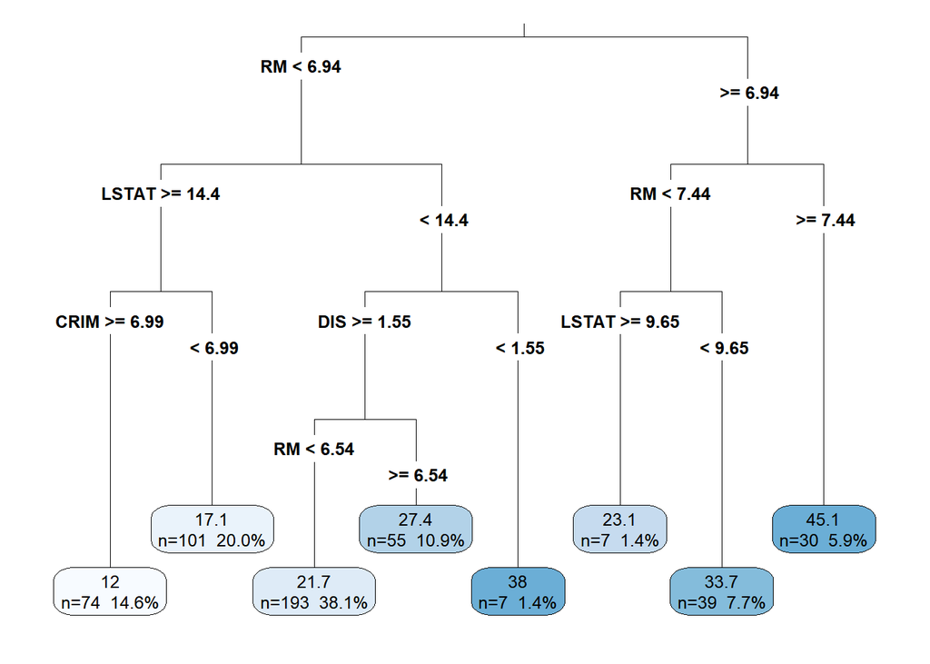

```r
rpart.plot(model, digits = 3, fallen.leaves = T, type = 3, extra = 101)
```

```r
#
# # 3.wine데이터를 train데이터와 test데이터로 나눈다
# data <- round(nrow(boston)*0.7)
# boston_train <- boston[1:data,]
# boston_test <- boston[(data+1):nrow(boston),]
# nrow(boston_train)
#
# # 4. train데이터를 가지고 model을 생성한다.
# library(rpart)
# attach(boston)
# model1 <- rpart(MEDV~., data = boston_train)
# model1
#
# # 5. 위의 model로 트리를 시각화하시오
# library(rpart.plot)
#
# rpart.plot(model1, digits = 3, fallen.leaves = T, type = 3, extra = 101)
#
# # 6. 위에서 만든 모델로 test데이터의 label을 예측하기
# # why label을 빼지 않고 하는거지?
# result <- predict(model1,boston_test)
#
# # 7. 테스트 데이터의 실제 라벨과 예측결과를 비교한다.
# table(ifelse( round(result) == boston_test$MEDV, 1, 0))
#
# # 8. 테스트 데이터의 라벨과 예측결과와 상관관계가 어떻게 되는지 확인한다.
# cor(result,boston_test$MEDV)
#
# # 9. 두 데이터간의 오차율을 확인
#
# # 5.4로 상대적으로 높게 나옴 -> 개선의 여지 필요
# MAE(result, boston_test$MEDV)
```